# **Laboratorio 3: Análisis Geoespacial**

- Derek Arreaga - 22537
- Mónica Salvatierra - 22249

Link del repositorio: https://github.com/alee2602/LAB3-DS

### **Importación de librerías y preprocesamiento de datos**

```python
import rasterio
import matplotlib.pyplot as plt
import numpy as np

before_04 = rasterio.open('images/2020/2020-01-01-00_00_2020-12-31-23_59_Sentinel-2_L2A_B04_(Raw).tiff')
before_08 =rasterio.open('images/2020/2020-01-01-00_00_2020-12-31-23_59_Sentinel-2_L2A_B08_(Raw).tiff')

then_04 = rasterio.open('images/2024/2024-02-27-00_00_2024-03-27-23_59_Sentinel-2_L2A_B04_(Raw).tiff')
then_08 = rasterio.open('images/2024/2024-02-27-00_00_2024-03-27-23_59_Sentinel-2_L2A_B08_(Raw).tiff')
```

### **Cálculo de NDVI**

```python
# Cargar bandas 2020
red_2020 = before_04.read(1).astype('float32')
nir_2020 = before_08.read(1).astype('float32')

# Cargar bandas 2024
red_2024 = then_04.read(1).astype('float32')
nir_2024 = then_08.read(1).astype('float32')

# Calcular NDVI 2020
NDVI_2020 = (nir_2020 - red_2020) / (nir_2020 + red_2020 + 1e-6)
print("Matriz NDVI 2020:")
print(NDVI_2020)

# Calcular NDVI 2024
NDVI_2024 = (nir_2024 - red_2024) / (nir_2024 + red_2024 + 1e-6)
print("Matriz NDVI 2024:")
print(NDVI_2024)

# Calcular diferencia de NDVI
NDVI_diff = NDVI_2024 - NDVI_2020
print("Matriz diferencia NDVI (2024 - 2020):")
print(NDVI_diff)
```

```
Matriz NDVI 2020:
[[0.8367326  0.8507802  0.8267093  ... 0.86339927 0.8657867  0.85069263]
 [0.8235716  0.826727   0.8284121  ... 0.852572   0.85899276 0.8829026 ]
 [0.84545666 0.85037893 0.850253   ... 0.86161596 0.8375921  0.8819043 ]
 ...
 [0.9049665  0.8461129  0.86988646 ... 0.60675085 0.5533206  0.5742957 ]
 [0.676762   0.87499785 0.8885413  ... 0.571158   0.53538126 0.52510095]
 [0.83536524 0.6908407  0.74648404 ... 0.6527441  0.5140743  0.5630943 ]]
Matriz NDVI 2024:
[[0.8004911  0.80652016 0.79972863 ... 0.7435217  0.7450956  0.7137099 ]
 [0.788081   0.8026295  0.78743464 ... 0.7205474  0.7286441  0.76825356]
 [0.8014163  0.79300857 0.8078557  ... 0.7478237  0.69299823 0.7608035 ]
 ...
 [0.8984819  0.8693561  0.8712052  ... 0.65705454 0.56689835 0.5118628 ]
 [0.76418495 0.8838633  0.8797307  ... 0.6482217  0.49622005 0.52721447]
 [0.86690694 0.7593665  0.8158052  ... 0.7117363  0.5827966  0.6932531 ]]
Matriz diferencia NDVI (2024 - 2020):
[[-0.03624153 -0.04426003 -0.02698064 ... -0.11987758 -0.12069106
  -0.13698274]
 [-0.03549063 -0.0240975  -0.04097748 ... -0.13202465 -0.13034868
  -0.11464906]
 [-0.04404038 -0.05737036 -0.04239726 ... -0.11379224 -0.1445939
  -0.12110078]
 ...
 [-0.00648457  0.02324319  0.00131875 ...  0.0503037   0.01357776
  -0.06243289]
 [ 0.08742297  0.00886542 -0.00881058 ...  0.07706368 -0.03916121
   0.00211352]
 [ 0.03154171  0.06852579  0.06932116 ...  0.05899221  0.06872225
   0.13015878]]
```

### **Aplicar umbral para marcar pérdida significativa de vegetación**

```python
threshold = -0.2
deforest_mask = NDVI_diff < threshold

deforest_mask = deforest_mask.astype(int)
```

### **Mapa NDVI 2020**

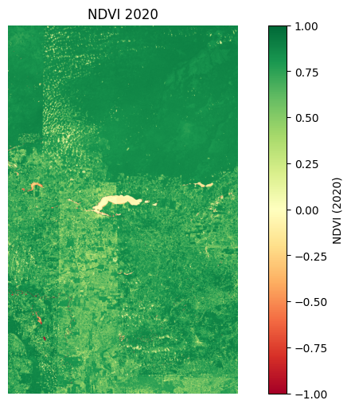

```python
plt.figure(figsize=(10, 6))
cmap = plt.cm.RdYlGn
plt.imshow(NDVI_2020, cmap=cmap, vmin=-1, vmax=1)
plt.colorbar(label='NDVI (2020)')
plt.title('NDVI 2020')
plt.axis('off')
plt.show()
```

El mapa correspondiente al NDVI del año 2020 muestra una predominancia de tonos verdes oscuros en la región noreste del área de estudio, lo que indica una alta densidad de vegetación y cobertura forestal abundante. Estos valores, cercanos a 1.0, son característicos de áreas boscosas densas como las que predominan en gran parte del departamento de Petén.

En contraste, en las zonas centrales y sur se observan tonalidades de verde más claro y amarillo, que corresponden a valores de NDVI intermedios. Esto implica la presencia de vegetación menos densa, posiblemente asociada a áreas agrícolas. Estas áreas representan una transición entre los bosques naturales y las zonas con mayor intervención humana.

Asimismo, se identifican pequeños parches de color rojo dispersos en el mapa. Estos valores negativos o cercanos a cero indican ausencia significativa de vegetación, pudiendo corresponder infraestructura urbana o zonas deforestadas. Entre estos puntos destacan los cuerpos de agua, visibles como manchas claras en el centro del mapa.

### **Mapa NDVI 2024**

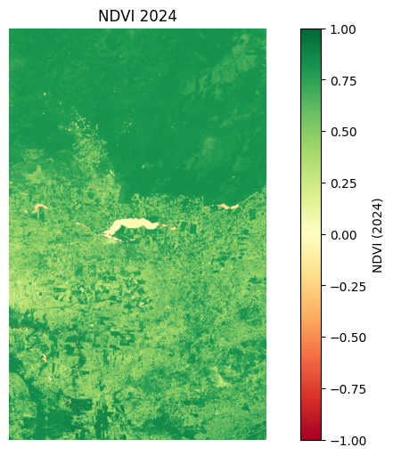

```python
plt.figure(figsize=(10, 6))
cmap = plt.cm.RdYlGn
plt.imshow(NDVI_2024, cmap=cmap, vmin=-1, vmax=1)
plt.colorbar(label='NDVI (2024)')
plt.title('NDVI 2024')
plt.axis('off')
plt.show()
```

El mapa del NDVI correspondiente al año 2024 presenta una distribución de valores que refleja cambios en la cobertura vegetal respecto al año 2020. En la parte norte y noreste del área de estudio persisten tonos verdes oscuros, con valores cercanos a 1.0, lo que representa áreas con vegetación densa y en buen estado.

Además, en las zonas centrales y sur predominan tonos de verde más claro y amarillo, lo que indica una menor densidad de vegetación. Se observan patrones más fragmentados en comparación con el mapa de 2020, con áreas discontinuas que marcan la presencia de zonas intervenidas por el ser humano. También destacan los cuerpos de agua visibles en el centro del mapa, que mantienen su ubicación y extensión general en relación con el periodo anterior.

### **Mapa de diferencia de NDVI**

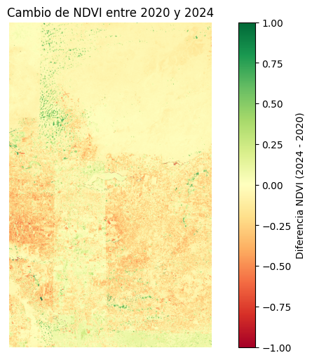

```python
plt.figure(figsize=(10, 6))
cmap = plt.cm.RdYlGn
plt.imshow(NDVI_diff, cmap=cmap, vmin=-1, vmax=1)
plt.colorbar(label='Diferencia NDVI (2024 - 2020)')
plt.title('Cambio de NDVI entre 2020 y 2024')
plt.axis('off')
plt.show()
```

El mapa de diferencia de NDVI muestra los cambios en la cobertura vegetal entre los años 2020 y 2024. Los tonos verdes representan áreas donde el índice de vegetación ha aumentado, mientras que los tonos rojos y anaranjados corresponden a zonas con disminución de NDVI, lo que indica pérdida de vegetación o degradación del suelo.

En gran parte de la zona central y sur predominan tonalidades rojas y anaranjadas, lo que evidencia una reducción significativa de la vegetación respecto al periodo anterior. Estas áreas coinciden con regiones que en 2020 presentaban valores intermedios de NDVI y que en 2024 muestran menor densidad o salud vegetal.

Las regiones verdes, aunque menos extensas, se concentran en sectores específicos al norte y en pequeños parches distribuidos en el sur. Estos incrementos de NDVI pueden asociarse a procesos de regeneración de vegetación o cambios en el uso del suelo que favorecieron la cobertura vegetal en esos puntos.

### **Máscara de deforestación**

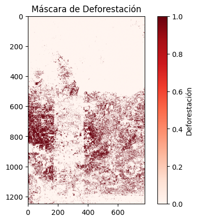

```python
plt.imshow(deforest_mask, cmap='Reds')
plt.colorbar(label='Deforestación')
plt.title('Máscara de Deforestación')
plt.show()
```

```python
percent_deforest = (deforest_mask.sum() / deforest_mask.size) * 100
print(f"Porcentaje de área deforestada: {percent_deforest:.2f}%")
```

```
Porcentaje de área deforestada: 15.52%
```

La máscara de deforestación identifica las áreas con pérdida significativa de vegetación entre 2020 y 2024, de acuerdo con el umbral aplicado sobre la diferencia de NDVI. En la imagen, las zonas en tonos rojos representan las áreas detectadas como deforestadas, mientras que las zonas claras corresponden a regiones sin cambios relevantes o con incremento en la cobertura vegetal.

El patrón espacial muestra que la deforestación se concentra principalmente en el sector sur y centro del área de estudio, con una distribución fragmentada y dispersa. Esto es consistente con el análisis previo de la diferencia de NDVI, donde estas zonas presentaban valores negativos pronunciados. El sector norte mantiene una menor proporción de áreas deforestadas, aunque se observan pequeños focos de pérdida vegetal.

El cálculo del porcentaje de área deforestada, obtenido al dividir el número de píxeles marcados como deforestación entre el total de píxeles del área de estudio, muestra un valor de **15.52%**. Este valor representa la proporción del área analizada que ha experimentado una disminución significativa de vegetación en el periodo evaluado.

### **Conclusiones**

El análisis de imágenes Sentinel-2 para los años 2020 y 2024 permitió identificar cambios significativos en la cobertura vegetal en la región de Petén. Los valores de NDVI evidenciaron que, aunque en 2024 persisten áreas con alta densidad de vegetación, se registraron reducciones notorias en la zona central y sur del departamento, donde se observa una mayor fragmentación y degradación de la cobertura forestal.

El patrón espacial de la deforestación sugiere que las zonas más impactadas se concentran en áreas con actividad humana y con uso intensivo, posiblemente en agricultura. Sin embargo, se observaron también pequeños incrementos de vegetación en ciertos sectores, que podrían relacionarse con procesos de regeneración natural o cambios en el uso del suelo.

En conjunto, los resultados demuestran la utilidad de las imágenes satelitales y del NDVI como herramientas para el monitoreo de la deforestación, aportando información valiosa para la gestión ambiental y la toma de decisiones orientadas a la conservación de los ecosistemas forestales.